# The_Presentation

December 18, 2017

## Introduction

In this report I analyze the tweets about the company Airbnb. Airbnb is the most tweeted brand in 2017, therefore it will be interesting to analyze the tweets associated with the brand. I here acquire the tweets from twitter using the package TwitterR and analyze the tweets. That is, I analyze the words associated with brand, and their frequencies. I also analyze the tweets sentiments.

## Data Acquisition

The data is imported from Twitter. I created the function GetTweets in order to search twitter and save the results as a data frame. Meanwhile, the function GetTweetsFrequency calculate the frequency of each word mentioned in any of the tweets.

## Twitter Authentication

After installing the Packages, I authenticate access to twitter

## Cleaning the data

After I have acquired the data, I now clean it by removing the unused columns from the data frame, and by omitting any rows with a missing value.

## Cleaning the frequency data frame.

I reorder the frequency data frame, and remove the words with frequency of one. Hence, they have little to no significance in the analysis.

## Cleaning the tweets data frame.

In this part I will be removing the unwanted columns and the rows with missing tweets. Since the number of the geocoded tweets is usually very low, I will divide the data frame into two; the first with the columns needed for analysis, and the second for the geocoded tweets. Then I will clean the data frames from missing values.

## Histogram.

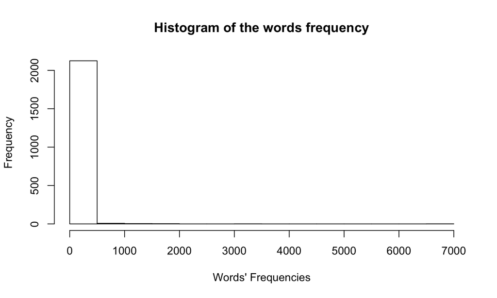

## Sentimental analysis

In this part of the report I use the function sentimentalTabel() to analyze the sentiment of the tweets collected. Since I acquired a large number of tweets, the sentimental analysis of the dataset I have should reflect the population's. It is clear that most of the tweets about Airbnb are positive, which indicates satisfaction of the services they provide.

## The plot

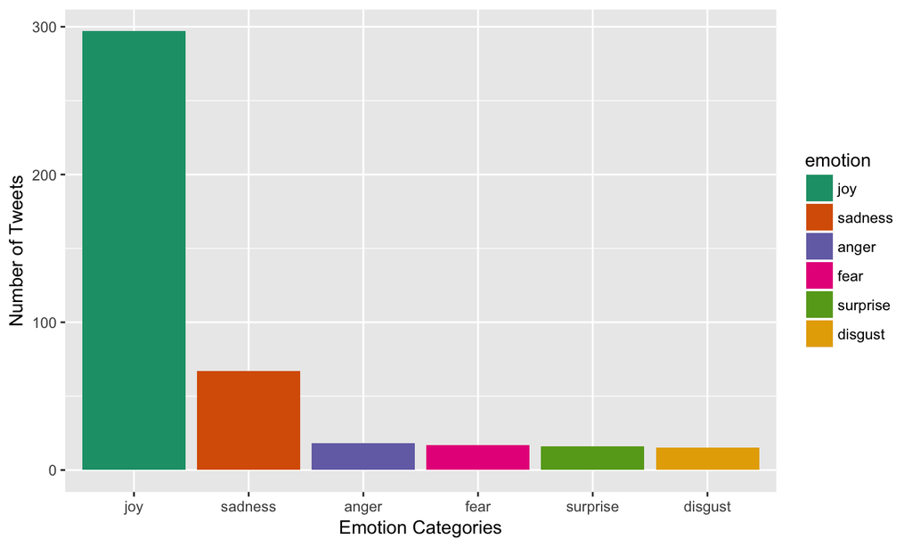

## Bar charts

The following bar chart represents the classification of the tweet from the perspective of it being a retweet.

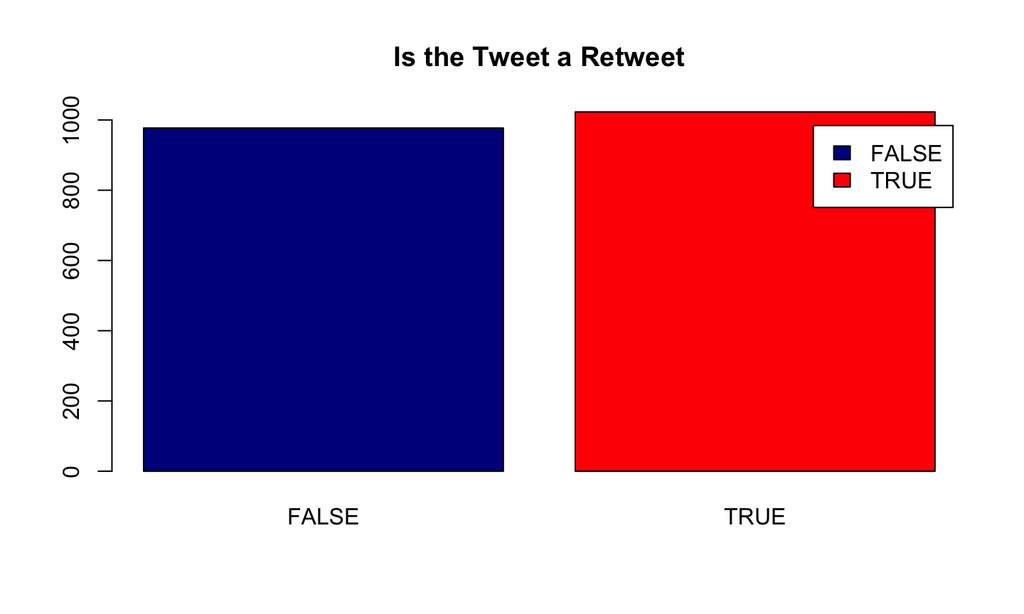

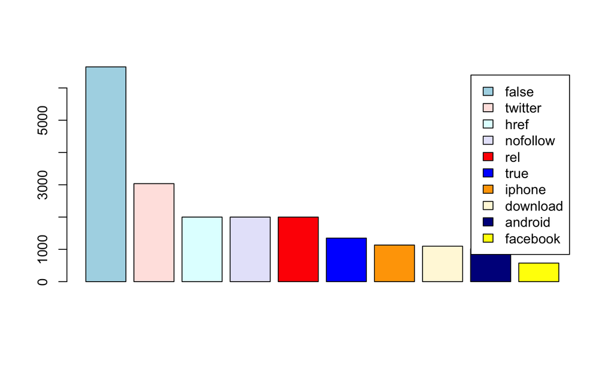

## Probability Equation

I constructed an equation that measure the probability of any word to be associated with the Brand depending on the sample of the tweets I have Acquired, using an if statement. For example, I used the word Canada and the following is the probability that the word Canada is associated with the Airbnb.

```
## [1] 0.00511522
```

## The Map

Here I used the package leaflet to construct a map that shows the location of the geocoded tweets. From the map it seems that most of Airbnb services are available in North America. However, I cannot infer that this is always true because of the small sample of geocoded tweets available.

## Map

[interactive chart not shown]